# Machine Learning Workflow-Naive Bayes

Bella Feng

November 16, 2017

### Machine Learning with R: Naive Bayes

Strengths: • Simple, fast, and very effective  
• Does well with noisy and missing data  
• Requires relatively few examples for training, but also works well with very large numbers of examples  
• Easy to obtain the estimated probability for a prediction  
Weaknesses:  
• Relies on an often-faulty assumption of equally important and independent features–>Naive  
• Not ideal for datasets with large numbers of numeric features  
• Estimated probabilities are less reliable than the predicted classes

The workflow consists of 7 steps

##### 1. Load data

##### 2. Observe data

##### 3. Preprocess data

##### 4. Split the data

##### 5. Train a model

##### 6. Evaluate the model

##### 7. Improve model performance

### 1. Load data

### 2. Observe data

```r
str(sms_raw)
```

```
## 'data.frame':    5573 obs. of  2 variables:
##  $ type: chr  "ham" "ham" "spam" "ham" ...
##  $ text: chr  "Go until jurong point, crazy.. Available only in bugis n great world la e buffet... Cine there got amore wat..." "Ok lar... Joking wif u oni..." "Free entry in 2 a wkly comp to win FA Cup final tkts 21st May 2005. Text FA to 87121 to receive entry question("| __truncated__ "U dun s…
```

```r
dim(sms_raw)
```

```
## [1] 5573    2
```

our y variable: type, need to be a factor

```r
table(sms_raw$type)
```

```
##
##  ham spam
## 4826  747
```

```r
str(sms_raw$type)
```

```
##  chr [1:5573] "ham" "ham" "spam" "ham" "ham" "spam" "ham" "ham" "spam" ...
```

```r
table(sms_raw$type)
```

```
##
##  ham spam
## 4826  747
```

### 3. Preprocess data

```r
library(tm)
sms_corpus <- Corpus(VectorSource(sms_raw$text))
#str(sms_corpus)
print(sms_corpus)
```

```
## <<SimpleCorpus>>
## Metadata:  corpus specific: 1, document level (indexed): 0
## Content:  documents: 5573
```

```r
inspect(sms_corpus[1:3])
```

```
## <<SimpleCorpus>>
## Metadata:  corpus specific: 1, document level (indexed): 0
## Content:  documents: 3
##
## [1] Go until jurong point, crazy.. Available only in bugis n great world la e buffet... Cine there got amore wat...
## [2] Ok lar... Joking wif u oni...
## [3] Free entry in 2 a wkly comp to win FA Cup final tkts 21st May 2005. Text FA to 87121 to receive entry question(std txt rate)T&C's apply 08452810075over18's
```

2. Clean up the corpus: to lower cases, remove numbers, punctuation, stop words, remove extra white spaces

```r
corpus_clean <- tm_map(sms_corpus, tolower)
corpus_clean <- tm_map(corpus_clean, removeNumbers)
corpus_clean <- tm_map(corpus_clean, removeWords, stopwords())
corpus_clean <- tm_map(corpus_clean, removePunctuation)
sms_corpus_clean <- tm_map(corpus_clean, stripWhitespace)
#inspect(corpus_clean[1:3])
```

3. Tokenization: The DocumentTermMatrix() function will take a corpus and create a data structure called a sparse matrix, in which the rows of the matrix indicate documents (that is, SMS messages) and the columns indicate terms (that is, words).

```r
sms_dtm <- DocumentTermMatrix(corpus_clean)
```

### 4. Split the data

We’ll begin by splitting the raw data frame:

```r
sms_raw_train <- sms_raw[1:4179, ]
sms_raw_test <- sms_raw[4180:5574, ]
```

Then the document-term matrix:

```r
sms_dtm_train <- sms_dtm[1:4179, ]
sms_dtm_test <- sms_dtm[4180:5573, ]
```

And finally, the corpus:

```r
sms_corpus_train <- corpus_clean[1:4179]
sms_corpus_test <- corpus_clean[4180:5573]
```

To confirm that the subsets are representative of the complete set of SMS data, let’s compare the proportion of spam in the training and test data frames:

```r
prop.table(table(sms_raw_train$type))
```

```
##
##       ham      spam
## 0.8648002 0.1351998
```

```r
prop.table(table(sms_raw_test$type))
```

```
##
##       ham      spam
## 0.8694405 0.1305595
```

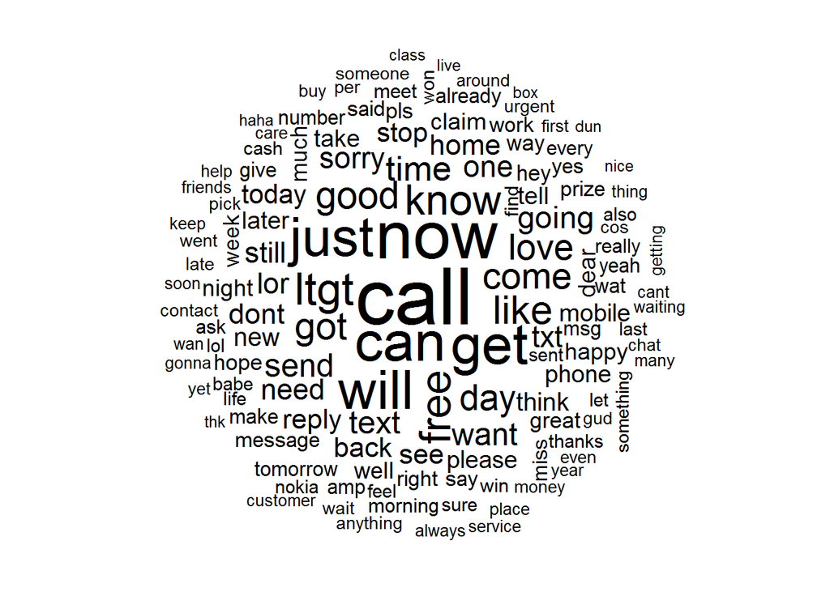

```r
library(wordcloud)
wordcloud(sms_corpus_train, min.freq = 40, random.order = FALSE)
```

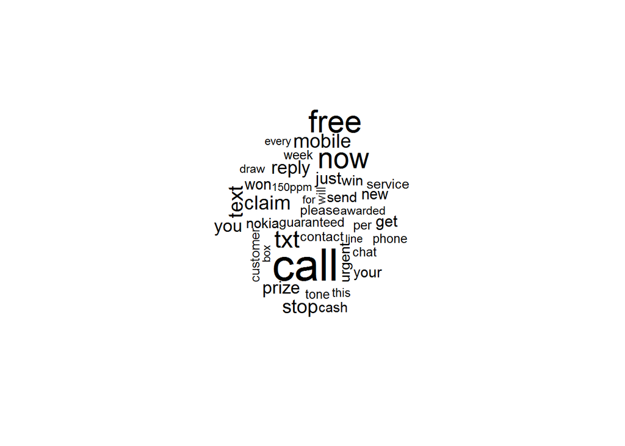

```r
library(wordcloud)
 spam <- subset(sms_raw_train, type == "spam")
 ham <- subset(sms_raw_train, type == "ham")
 wordcloud(spam$text, max.words = 40, scale = c(3, 0.5))
```

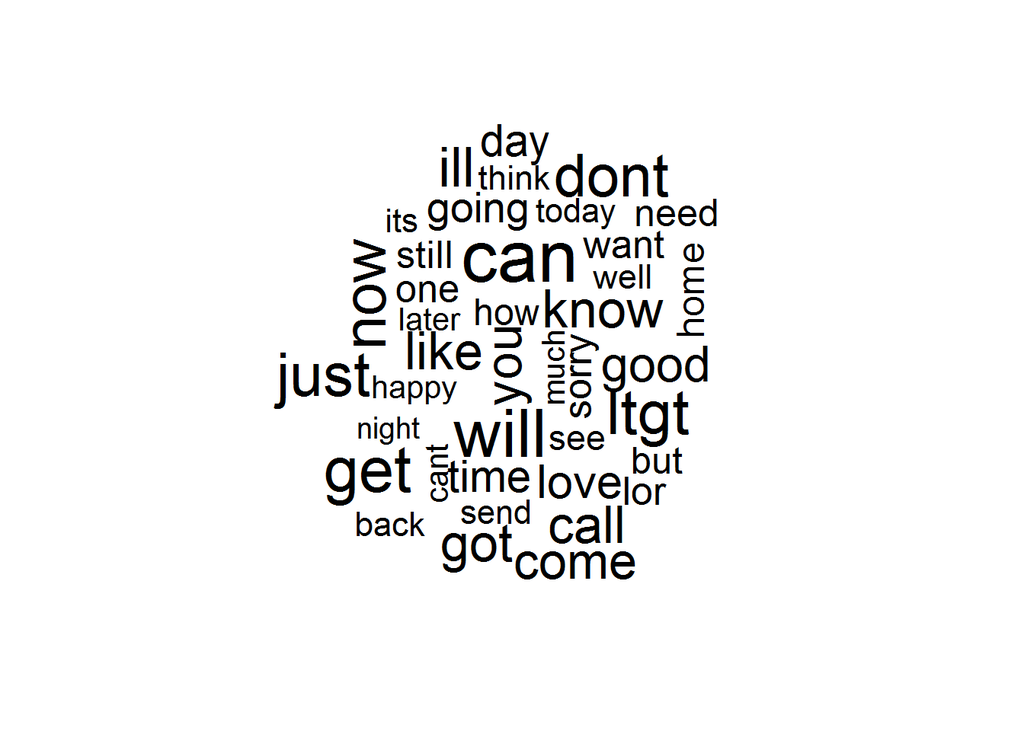

```r
wordcloud(ham$text, max.words = 40, scale = c(3, 0.5))
```

The final step in the data preparation process is to transform the sparse matrix into a data structure that can be used to train a naive Bayes classifier.

```r
frequent_terms <- findFreqTerms(sms_dtm_train,5)
sms_dtm_freq_train <- sms_dtm_train[,frequent_terms]
sms_dtm_freq_test <- sms_dtm_test[,frequent_terms]
```

The naive Bayes classifier is typically trained on data with categorical features. This poses a problem since the cells in the sparse matrix indicate a count of the times a word appears in a message. We should change this to a factor variable that simply indicates yes or no depending on whether the word appears at all. The following code defines a convert_counts() function to convert counts to factors:

```r
convert_counts <- function(x){
  x <- ifelse(x > 0,"Yes","No")
}
sms_train <- apply(sms_dtm_freq_train,MARGIN = 2,   convert_counts)
sms_test <- apply(sms_dtm_freq_test,MARGIN = 2,     convert_counts)
```

### 5. Train a model

[output not shown]

[output not shown]

```r
sms_model1 <- train(sms_train, sms_raw_train$type, method="nb",
                    trControl=ctrl)
sms_test_pred <- predict(sms_model1, sms_test)
library(gmodels)
CrossTable(sms_test_pred, sms_raw_test$type,
           prop.chisq = FALSE, prop.t = FALSE,
           dnn = c('predicted', 'actual'))
```

```
##
##
##    Cell Contents
## |-------------------------|
## |                       N |
## |           N / Row Total |
## |           N / Col Total |
## |-------------------------|
##
##
## Total Observations in Table:  1392
##
##
##              | actual
##    predicted |       ham |      spam | Row Total |
## -------------|-----------|-----------|-----------|
##          ham |      1127 |       162 |      1289 |
##              |     0.874 |     0.126 |     0.926 |
##              |     0.934 |     0.871 |           |
## -------------|-----------|-----------|-----------|
##         spam |        79 |        24 |       103 |
##              |     0.767 |     0.233 |     0.074 |
##              |     0.066 |     0.129 |           |
## -------------|-----------|-----------|-----------|
## Column Total |      1206 |       186 |      1392 |
##              |     0.866 |     0.134 |           |
## -------------|-----------|-----------|-----------|
##
##
```